# Reproduciable Research - Week 2 Assignment

### 1. Load the Data

```r
actv_data<-read.csv("activity.csv",header =TRUE)
```

##### a.Verify the Summary of the data

```r
summary(actv_data)
```

```
##      steps                date          interval
##  Min.   :  0.00   2012-10-01:  288   Min.   :   0.0
##  1st Qu.:  0.00   2012-10-02:  288   1st Qu.: 588.8
##  Median :  0.00   2012-10-03:  288   Median :1177.5
##  Mean   : 37.38   2012-10-04:  288   Mean   :1177.5
##  3rd Qu.: 12.00   2012-10-05:  288   3rd Qu.:1766.2
##  Max.   :806.00   2012-10-06:  288   Max.   :2355.0
##  NA's   :2304     (Other)   :15840
```

### 2.Process and transform the data into a format suitable for your analysis

```r
actv_trfm_data <- na.omit(actv_data)
```

## What is the mean total of steps taken in a day?

#### 1. Total number of steps taken per Day

```r
library("dplyr")
actv_day<-group_by(actv_trfm_data,date)
actv_day<-summarise(actv_day,steps=sum(steps))
```

#### 2. Histogram of total number of steps taken in a day

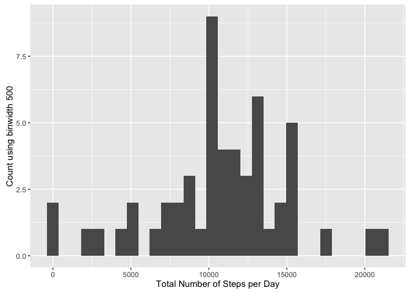

```r
library("ggplot2")
qplot(actv_day$steps,xlab="Total Number of Steps per Day",ylab="Count using binwidth 500")
```

#### 3. Mean and Median of Steps taken in a day

```r
mean(actv_day$steps)
```

```
## [1] 10766.19
```

```r
median(actv_day$steps)
```

```
## [1] 10765
```

## What is average daily activity Pattern?

#### 1. Make a time series plot (i.e. 𝚝𝚢𝚙𝚎 = “𝚕”) of the 5-minute interval (x-axis) and the average number of steps taken, averaged across all days (y-axis)

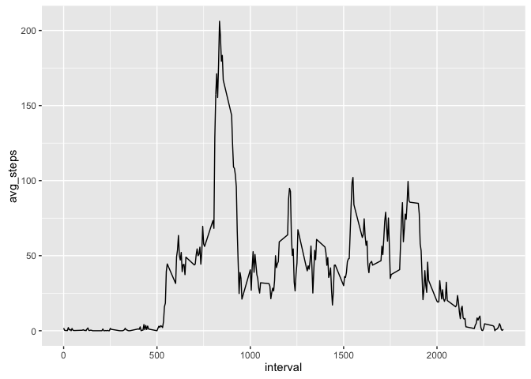

```r
actv_day_avg<-group_by(actv_trfm_data,interval)
actv_day_avg<-summarise(actv_day_avg,avg_steps=mean(steps))
ggplot(actv_day_avg,aes(interval,avg_steps)) +geom_line()
```

#### 2. Which 5-minute interval, on average across all the days in the dataset, contains the maximum number of steps?

```r
actv_day_avg[actv_day_avg$avg_steps==max(actv_day_avg$avg_steps),]
```

```
## Source: local data frame [1 x 2]
##
##   interval avg_steps
##      <int>     <dbl>
## 1      835  206.1698
```

## Imputing missing values

#### 1. Calculate and report the total number of missing values in the dataset (i.e. the total number of rows with 𝙽𝙰s)

```r
nrow(actv_data)-nrow(actv_trfm_data)
```

```
## [1] 2304
```

[output not shown]

#### 3. Create a new dataset that is equal to the original dataset but with the missing data filled in

```r
actv_impute$steps[is.na(actv_impute$steps)]<-actv_impute$avg_steps[is.na(actv_impute$steps)]
```

[output not shown]

`` ## `stat_bin()` using `bins = 30`. Pick better value with `binwidth`. ``

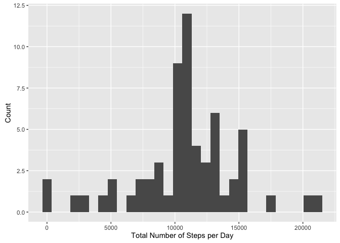

`## [1] 10766.19`

`## [1] 10766.19`

## Are there differences in activity patterns between weekdays and weekends?

#### 1. Create a new factor variable in the dataset with two levels – “weekday” and “weekend” indicating whether a given date is a weekday or weekend day.

```r
actv_impute$dayofweek<-weekdays(as.Date(actv_impute$date))
actv_impute$WeekDay <-as.factor(actv_impute$dayofweek=="Saturday"|actv_impute$dayofweek=="Sunday")
levels(actv_impute$WeekDay)<-c("Weekday","Weekend")
```

#### 2. Make a panel plot containing a time series plot (i.e. 𝚝𝚢𝚙𝚎 = “𝚕”) of the 5-minute interval (x-axis) and the average number of steps taken, averaged across all weekday days or weekend days (y-axis).

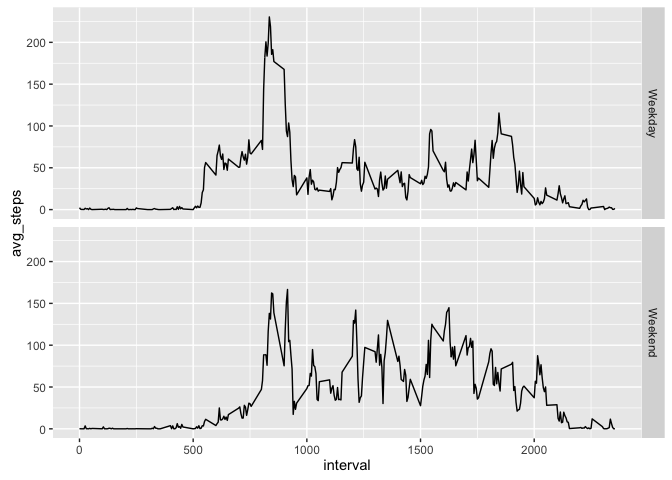

```r
actv_weekday<-actv_impute[actv_impute$WeekDay=="Weekday",]
actv_weekend<-actv_impute[actv_impute$WeekDay=="Weekend",]
actv_weekday_avg<-group_by(actv_weekday,interval)
actv_weekday_avg<-summarise(actv_weekday_avg,avg_steps=mean(steps))
actv_weekday_avg$week<-"Weekday"
actv_weekend_avg<-group_by(actv_weekend,interval)
actv_weekend_avg<-summarise(actv_weekend_avg,avg_steps=mean(steps))
actv_weekend_avg$week<-"Weekend"

actv_imp_plot<-rbind(actv_weekday_avg,actv_weekend_avg)
ggplot(actv_imp_plot,aes(interval,avg_steps)) + geom_line() + facet_grid(week ~ .)
```